# Lab 1 - Checkpoint 2 - Minhas perguntas

Caio Oliveira

March 26, 2018

# Introdução

A ideia desse laboratório, para a disciplina de **FPCC2**, é fazer nos familiarizarmos mais com variáveis de um dataset qualquer e aprender a responder de forma gráfica, e simples, à perguntas sobre os [dados](https://github.com/nazareno/travistorrent-eda/blob/master/data/projetos.csv) em questão.

….

# 1- Como são os tamanhos de time nos projetos que usam travis em Java e em Ruby nos nossos dados?

Primeiramente para respondermos essa pergunta temos que nos livrar dos dados indesejados. No caso todos aqueles que não correspondem o **lang** com *Java* ou *Ruby*.

Após fazer isso temos um recorte dos dados abaixo, para saber como ele se comporta e principalmente suas *features*, as quais iremos selecionar aqui neste notebook para responder as perguntas propostas pelo professor.

A ideia inicial para respoder essa pergunta é ver qual a proporção de equipes em relação a cada uma das duas linguagens e observarmos também principalmente a distribuição dos dados em relação a quantidade de membros em um time por linguagem.

```r
library(dplyr)
library(ggplot2)
library(readr)
library(plotly)
library(knitr)

data <- read.csv("data/projetos.csv")
```

```r
data_filtered <- data  %>%
                 filter(lang == "java" | lang == "ruby")
kable(data_filtered[1:5,1:8], caption="Recorte dos dados filtrados")
```

Recorte dos dados filtrados

| gh_project_name | team | lang | sloc_end | sloc_med | activity_period | num_commits | commits_per_month |
| --- | --- | --- | --- | --- | --- | --- | --- |
| 47deg/appsly-android-rest | 6 | java | 3741 | 2366.0 | 10 | 97 | 9.70000 |
| abarisain/dmix | 7 | java | 43665 | 21095.5 | 35 | 1588 | 45.37143 |
| AChep/AcDisplay | 3 | java | 27734 | 21277.0 | 20 | 1146 | 57.30000 |
| activeadmin/activeadmin | 19 | ruby | 7029 | 6759.0 | 28 | 8579 | 306.39286 |
| ActiveJpa/activejpa | 2 | java | 2713 | 2627.0 | 24 | 247 | 10.29167 |

A melhor maneira de vermos a dispersão dos dados de uma forma intuitiva é usando o **violin plot**. Essa ferramenta nos dá a possibilidade de vermos rapidamente onde se concentram os dados e se são uniformemente distribuidos. Faremos esse gráfico com as variáveis da quantidade de membros de um time (**team**) e agrupados por linguagem.

Entretanto para esses dados essa visualização, sem nenhuma normalização, não irá nos ajudar a obter a resposta para a pergunta. Os dados tem uma diferença muito grande entre si, e para podermos visualizar melhor iremos aplicar a seguir.

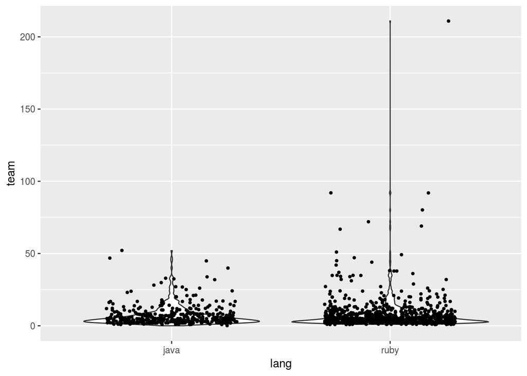

```r
p <- ggplot(data_filtered, aes(x=lang, y=team)) +
  geom_violin()  + geom_jitter(shape=20, position=position_jitter(0.3))
p
```

Agora o gráfico ficou bem mais intuitivo, e podemos ver que apesar da concentração maior de dados para a linguagem *Ruby*, as duas distribuições são bem parecidas, concentrando os dados abaixo de 50 pessoas por time.

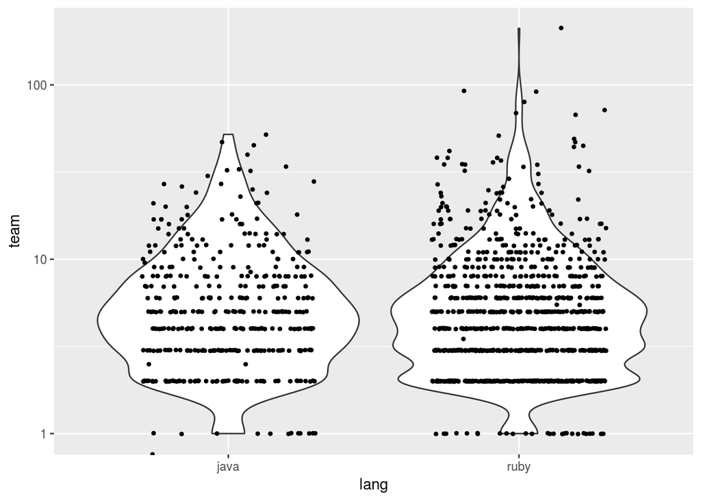

```r
p <- ggplot(data_filtered, aes(x=lang, y=team)) +
  geom_violin() + scale_y_log10() + geom_jitter(shape=20, position=position_jitter(0.3))
p
```

Essa mesma visualização do **violin plot** pode ser vista com outra ferramenta integrada a ela, que é o **boxplot**. Esse tipo de gráfico nos mostra mesma coisa que o anterior mas de uma forma resumida e menos poluida visualmente.

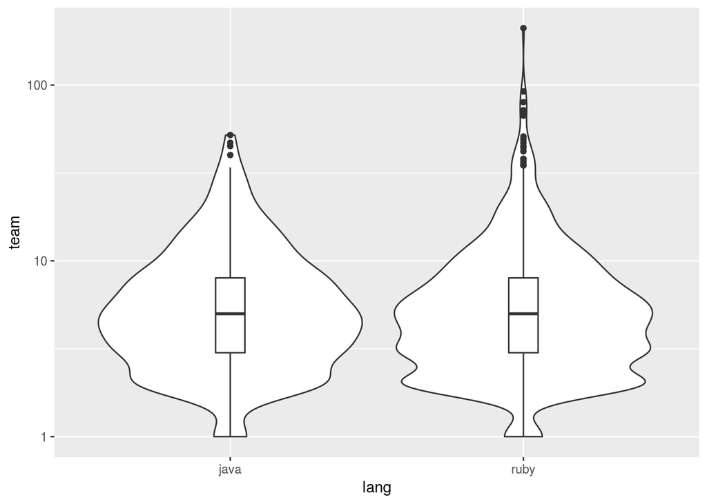

```r
p <- ggplot(data_filtered, aes(x=lang, y=team)) +
  geom_violin() + scale_y_log10() + geom_boxplot(width=0.1)
p
```

Talvez uma das coisas mais importantes quando mexemos com um dataset é verificarmos se nossos dados são balanceados, pois esse procedimento pode nos ajudar bastante na escolha, por exemplo, de algoritmos de aprendizagem de máquina.

Para esse notebook a intenção de vermos a diferença nos dados é só para sabermos se a quantidade de times tem relação direta com o tamanho dos mesmos nos projetos.

Aqui podemos ver que os dados são desbalanceados em relação a linguagem *Ruby* que possui mais que o dobro de projetos em relação a *Java*.

```r
p <- plot_ly(data_filtered,y = ~lang, type = "histogram")
p
```

[interactive chart not shown]

Por fim podemos comparar no mesmo gráfico os dois histogramas, um para cada linguagem, em relação a frequência na quantidade de membros em um time.

Para melhor visualização este gráfico é interativo e pode-se aproximar de uma determinada faixa do eixo x e y.

Com esse gráfico concluimos que para a linguagem *Ruby* a frequência de times é bem maior que para *Java* na mesma quantidade de integrantes.

```r
java <- data_filtered %>%
        filter(lang == "java")

ruby <- data_filtered %>%
        filter(lang == "ruby")

s <- seq(1, 50, by = 0.12)
p <- plot_ly(alpha = 0.6) %>%
  add_histogram(data=java, y = ~team, name = "Java") %>%
  add_histogram(data=ruby, y = ~team, name= "Ruby") %>%
  layout(barmode = "overlay")
p
```

[interactive chart not shown]

# 2- Ao comparar projetos em Java e em Ruby que tenham ao menos 10 contribuidores no time nos nossos dados, projetos de qual linguagem variam mais na proporção de builds cujo resultado é sucesso?

Para respondermos essa pergunta não podemos continuar utilizando os mesmos dados de antes. Uma nova filtragem é necessária tendo como pivot agora a *feature* **team** maior ou igual a 10.

Podemos ver a seguir como os dados ficaram em outro recorte para análise e que na qual nessa sessão focaremos todas as análises com a coluna **build_success_prop**.

```r
data_plus_ten <- data_filtered %>%
                 filter(team  >= 10)
kable(data_plus_ten[1:5,1:8],caption = "Dados com mais de 10 na equipe")
```

Dados com mais de 10 na equipe

| gh_project_name | team | lang | sloc_end | sloc_med | activity_period | num_commits | commits_per_month |
| --- | --- | --- | --- | --- | --- | --- | --- |
| activeadmin/activeadmin | 19 | ruby | 7029 | 6759 | 28 | 8579 | 306.39286 |
| activerecord-hackery/ransack | 13 | ruby | 3629 | 3414 | 36 | 46836 | 1301.00000 |
| airlift/airlift | 11 | java | 26971 | 24196 | 32 | 732 | 22.87500 |
| amatsuda/kaminari | 10 | ruby | 970 | 891 | 48 | 28780 | 599.58333 |
| antirez/redis-doc | 11 | ruby | 283 | 206 | 38 | 1798 | 47.31579 |

Sempre que falamos de variação em dados, o **Boxplot** é sempre uma forma segura de verificarmos essa características conjuntamente a outras.

Para este caso o **violin plot** adicionado ao **Boxplot** nos dá a noção de variação + distribuição. O que podemos ver aqui que apesar de similares, essas duas distribuições tem diferenças sutis.

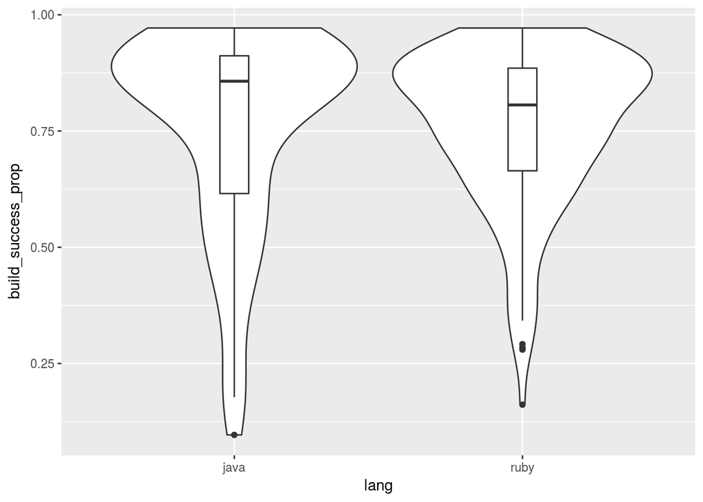

```r
p <- ggplot(data_plus_ten, aes(x=lang, y=build_success_prop)) +
  geom_violin()  + geom_boxplot(width=0.1)
p
```

Agora fazendo essa mesma visualização mas com o gráfico de dispersão ao invés do **boxplot** podemos confirmar a quantidade de dados se concentrando acima para linguagem *Ruby*.

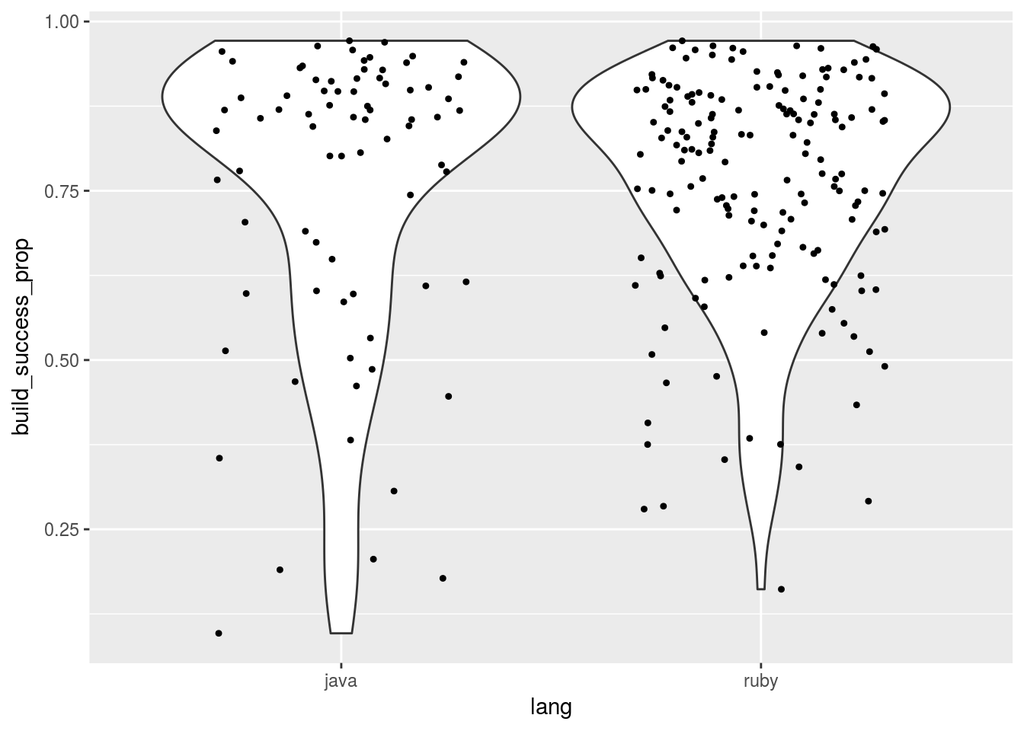

```r
p <- ggplot(data_plus_ten, aes(x=lang, y=build_success_prop)) +
  geom_violin()  + geom_jitter(shape=20, position=position_jitter(0.3))
p
```

Por fim, o **Boxplot** de forma interativa nos mostra que *Java* tem uma variação maior em relação a quantidade de builds proporcionais.

```r
p <- plot_ly(data=data_plus_ten, x = ~lang,y = ~build_success_prop, type = "box")
p
```

[interactive chart not shown]